# Do Risky Neighborhoods Attract More Vulnerable Residents? Evidence from Hurricane Katrina

# 1 Questions

Do affected areas attract  
lower income residents?  
minorities?  
less creditworthy residents?

# 2 Related Articles

https://www.wsj.com/articles/climate-fears-reshape-miamis-housing-market-1524225600  
http://iopscience.iop.org/article/10.1088/1748-9326/aabb32?mod=article_inline  
https://papers.ssrn.com/sol3/papers.cfm?abstract_id=3073842  
https://www.fastcompany.com/90204840/coastal-cities-are-already-in-the-grips-of-climate-gentrification https://www.youtube.com/watch?v=MWY_b-vpo4E https://www.youtube.com/watch?v=jR6bw90S3ps

# 3 Setup

Treatment Group: Census Tracts directly affected by Hurricane Katrina Flooding  
Control Group: Census Tracts not directly affected by Hurricane Katrina Flooding

# 4 Data

HMDA Loan Application Register Data  
FEMA GIS Layer for Hurricane Katrina  
ZTRAX  
Census Data

# 5 Treatment Census Tracts

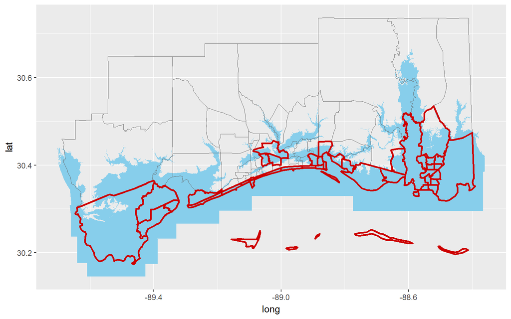

# 6 Control Census Tracts

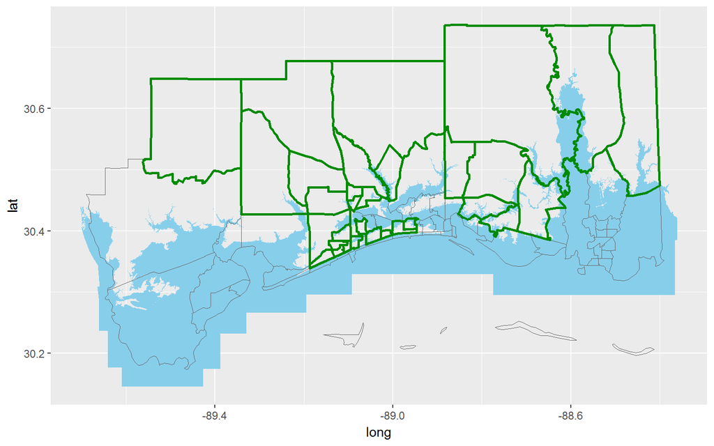

# 7 Descriptives - Treatment (New purchases, owner-occupied)

```
##
## ===================================================================
## Statistic          Mean    St. Dev. Pctl(25) Median Pctl(75)   N
## -------------------------------------------------------------------
## asofdate        2,004.8970  2.5268   2,003   2,005   2,007   30,998
## amountofloan     109.2944  79.0019     63      93     134    30,998
## applicantincome  63.5396   69.3176     34      47      71    27,547
## nonwhite          0.3696    0.4827     0       0       1     30,998
## approved          0.5152    0.4998     0       1       1     30,998
## -------------------------------------------------------------------
##
```

# 8 Descriptives - Control (New purchases, owner-occupied)

```
##
## ===================================================================
## Statistic          Mean    St. Dev. Pctl(25) Median Pctl(75)   N
## -------------------------------------------------------------------
## asofdate        2,005.0970  2.6003   2,003   2,005   2,007   46,110
## amountofloan     110.1804  72.4030     61     100     145    46,110
## applicantincome  59.8552   75.3192     34      48      70    40,686
## nonwhite          0.3521    0.4776     0       0       1     46,110
## approved          0.5088    0.4999     0       1       1     46,110
## -------------------------------------------------------------------
##
```

# 9 New Purchases, Owner occupied

```
##
## ========================================================================
##                                      Dependent variable:
##                      ---------------------------------------------------
##                      log(applicantincome) nonwhite  approved  ratespread
##                              (1)             (2)       (3)       (4)
## ------------------------------------------------------------------------
## post
##                            (0.000)         (0.000)   (0.000)   (0.000)
##
## treat                      0.079**         0.047*     0.007    -0.585**
##                            (0.040)         (0.025)   (0.012)   (0.278)
##
## nonwhite                  -0.147***                 -0.164***   0.013
##                            (0.019)                   (0.019)   (0.229)
##
## log(applicantincome)                      -0.097*** 0.118***  -0.424***
##                                            (0.014)   (0.008)   (0.128)
##
## primaryfemale             -0.224***        -0.013   0.021***    -0.042
##                            (0.021)         (0.020)   (0.008)   (0.061)
##
## jointapplication           0.333***       0.065***  -0.055***  0.141**
##                            (0.013)         (0.019)   (0.012)   (0.059)
##
## post:treat                -0.048***       0.019***  -0.031**    0.089
##                            (0.004)         (0.006)   (0.013)   (0.356)
##
## ------------------------------------------------------------------------
## Observations                68,233         63,987    68,233     4,561
## R2                          0.130           0.037     0.055     0.051
## Adjusted R2                 0.130           0.036     0.054     0.048
## ========================================================================
## Note:                                        *p<0.1; **p<0.05; ***p<0.01
```

# 10 Income Regression Parallel Trends (New Purchases, Owner occupied)

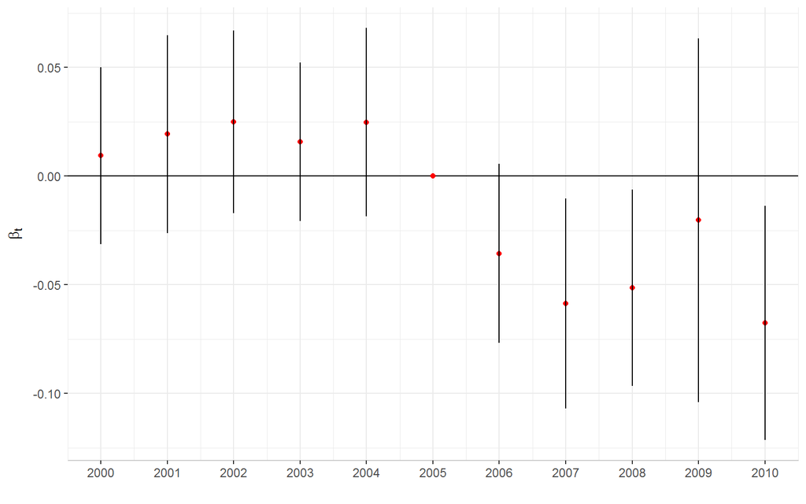

# 11 Non-white Regression Parallel Trends (New Purchases, Owner occupied)

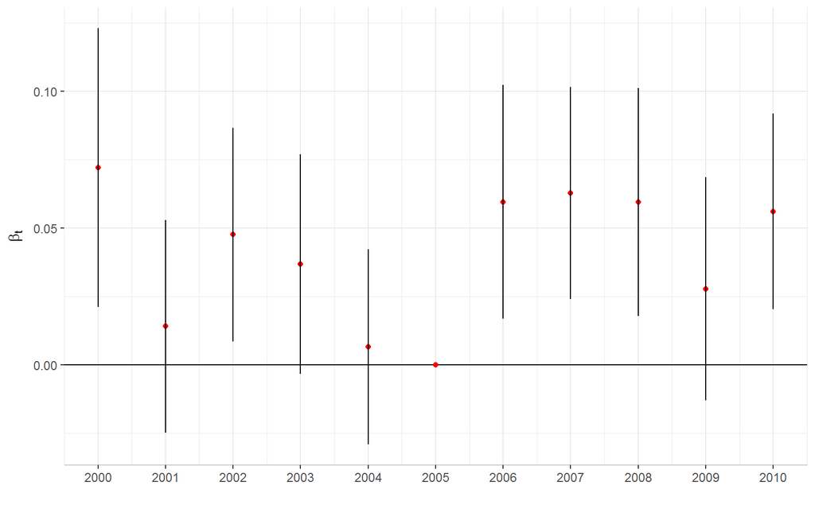

# 12 New Purchases, Non-owner occupied

```
##
## ========================================================================
##                                      Dependent variable:
##                      ---------------------------------------------------
##                      log(applicantincome) nonwhite  approved  ratespread
##                              (1)             (2)       (3)       (4)
## ------------------------------------------------------------------------
## post
##                            (0.000)         (0.000)   (0.000)   (0.000)
##
## treat                      0.187***         0.003    -0.011    -0.383**
##                            (0.052)         (0.032)   (0.014)   (0.183)
##
## nonwhite                  -0.084***                 -0.128***   -0.011
##                            (0.024)                   (0.020)   (0.180)
##
## log(applicantincome)                      -0.034*** 0.054***   -0.163*
##                                            (0.010)   (0.012)   (0.087)
##
## primaryfemale             -0.251***         0.006    -0.012     -0.090
##                            (0.031)         (0.009)   (0.011)   (0.159)
##
## jointapplication           0.171***       0.033***    0.005     -0.233
##                            (0.049)         (0.010)   (0.011)   (0.215)
##
## post:treat                 0.089**         -0.034    -0.011     -0.167
##                            (0.036)         (0.029)   (0.023)   (0.145)
##
## ------------------------------------------------------------------------
## Observations                12,433         11,276    12,433     1,283
## R2                          0.146           0.022     0.033     0.044
## Adjusted R2                 0.145           0.021     0.032     0.034
## ========================================================================
## Note:                                        *p<0.1; **p<0.05; ***p<0.01
```

# 13 Refinances, Owner-occupied

```
##
## ========================================================================
##                                      Dependent variable:
##                      ---------------------------------------------------
##                      log(applicantincome) nonwhite  approved  ratespread
##                              (1)             (2)       (3)       (4)
## ------------------------------------------------------------------------
## post
##                            (0.000)         (0.000)   (0.000)   (0.000)
##
## treat                       0.062*         0.052*    0.021**   -0.189**
##                            (0.037)         (0.031)   (0.009)   (0.092)
##
## nonwhite                  -0.162***                 -0.260***  0.155**
##                            (0.038)                   (0.028)   (0.073)
##
## log(applicantincome)                      -0.106*** 0.050***   -0.193*
##                                            (0.021)   (0.013)   (0.114)
##
## primaryfemale             -0.267***        -0.060     0.009     0.010
##                            (0.022)         (0.050)   (0.010)   (0.113)
##
## jointapplication           0.344***        -0.013     0.010     -0.119
##                            (0.012)         (0.011)   (0.009)   (0.103)
##
## post:treat                 -0.024**         0.006    -0.013     -0.120
##                            (0.011)         (0.007)   (0.011)   (0.096)
##
## ------------------------------------------------------------------------
## Observations               104,763         93,010    104,763    5,324
## R2                          0.122           0.090     0.080     0.022
## Adjusted R2                 0.121           0.090     0.080     0.019
## ========================================================================
## Note:                                        *p<0.1; **p<0.05; ***p<0.01
```

# 14 Future work

Startups?  
Buyer location?  
House price growth?  
Voting. Left or right?  
How does climate change impact the societies, climate gentrification.

Climate change impacts arguably make some property more or less valuable by virtue of its capacity to accommodate a certain density of human settlement and its associated infrastructure. In other words, climate change will speed up the process of gentrification in coastal cities by constricting the supply of livable land, and rendering it very expensive due to scarcity. As that happens, lower-income people will struggle to remain in place. Keenan, Hill, and Gumber found ample evidence that this is already happening in Miami. The coastal city is seeing property values on high-elevation lands skyrocket, while once pricey waterfront property values are diminishing.